# Set up a PostgreSQL database

# Creating the tables

## PDO

We now need to create the tables for the data within the database. We’ll begin with the PDO data.

- In **pgAdmin**, click the `Tools` tab at the top and then select `Query Tool`

[figure not shown]

- A query editor window will open in **pgAdmin**
- Click on the open folder icon, which will allow you to select the SQL file we saved above

[figure not shown]

- Navigate to the location where you saved your `pdo_data.sql`, select it, and then click the blue **Select** button

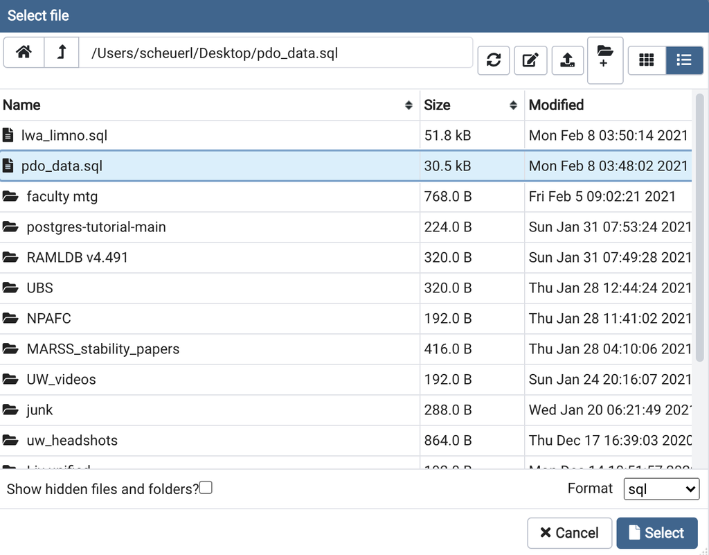

- You will now see the SQL code in the editor window, that begins with

```
CREATE TABLE public.pdo(
   date INTEGER  NOT NULL PRIMARY KEY
  ,pdo  NUMERIC(5,2) NOT NULL
);
INSERT INTO public.pdo(date,pdo) VALUES
 (185401,0.11)
,(185402,-0.24)
,(185403,-0.4)
,(185404,-0.44)
,(185405,-0.54)
,(185406,-0.3)
```

[figure not shown]

- Click the triangular play button at the top to execute the **SQL**
- The code should execute now and **pgAdmin** should respond

```
INSERT 0 2004

Query returned successfully in 42 msec.
```

(Note that the time it took the query to run will depend on your computer resources.)

[figure not shown]

- In the **pgAdmin** object browser, click on `Schemas > public > Tables > pdo` to see the contents of your new table `pdo`
- Right click on the `pdo` table and then click `View/Edit Data` and then `All Rows`

[figure not shown]

- The query editor will show you the following query used to call all records for the table in the upper pane and show the result set for that query in the lower pane.

```
SELECT * FROM public.pdo
ORDER BY date ASC
```

[figure not shown]

## Limnology

- In **pgAdmin**, click the `Tools` tab at the top and then select `Query Tool`

[figure not shown]

- A query editor window will open in **pgAdmin**
- Click on the open folder icon, which will allow you to select the SQL file we saved above

[figure not shown]

- Navigate to the location where you saved your `lwa_limno.sql`, select it, and then click the blue **Select** button

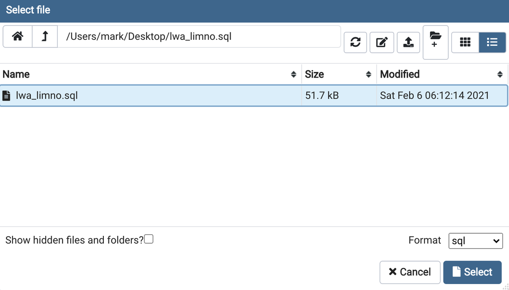

- You will now see the SQL code in the editor window, that begins with

```
CREATE TABLE staging.limno(
   Year                  INTEGER  NOT NULL
  ,Month                 INTEGER  NOT NULL
```

[figure not shown]

- Click the triangular play button at the top to execute the **SQL**
- The code should execute now and **pgAdmin** should respond

```
INSERT 0 396

Query returned successfully in 58 msec.
```

(Note that the time it took the query to run will depend on your computer resources.)

[figure not shown]

[figure not shown]

- The query editor will show you the following query used to call all records for the table in the upper pane and show the result set for that query in the lower pane.

```
SELECT * FROM staging.limno
```

[figure not shown]

# The Truman options

There can be times when it simply seems easiest to burn it all down and start over, so don’t feel bad if you find yourself here.

## Delete a database

If, for whatever reason, you want to delete a database, do this in **pgAdmin**

- Right-click on the `lake_wa` database and select `Delete/Drop`

[figure not shown]

## Delete a user

You cannot delete a user while you are logged in as that person. To remove the `lake_wa` user we created here, we’ll have to first disconnect from the database, and then log back in as the `postgres` super user. To do so in **pgAdmin**, follow these steps

1. Right-click on **PostgreSQL 13** in the object browser and select `Disconnect Server`

[figure not shown]

2. Right-click on **PostgreSQL 13** again and select `Properties`

[figure not shown]

3. Click on the `Connection` tab and change `username` to `postgres`; when you are done, click the blue **Save** button

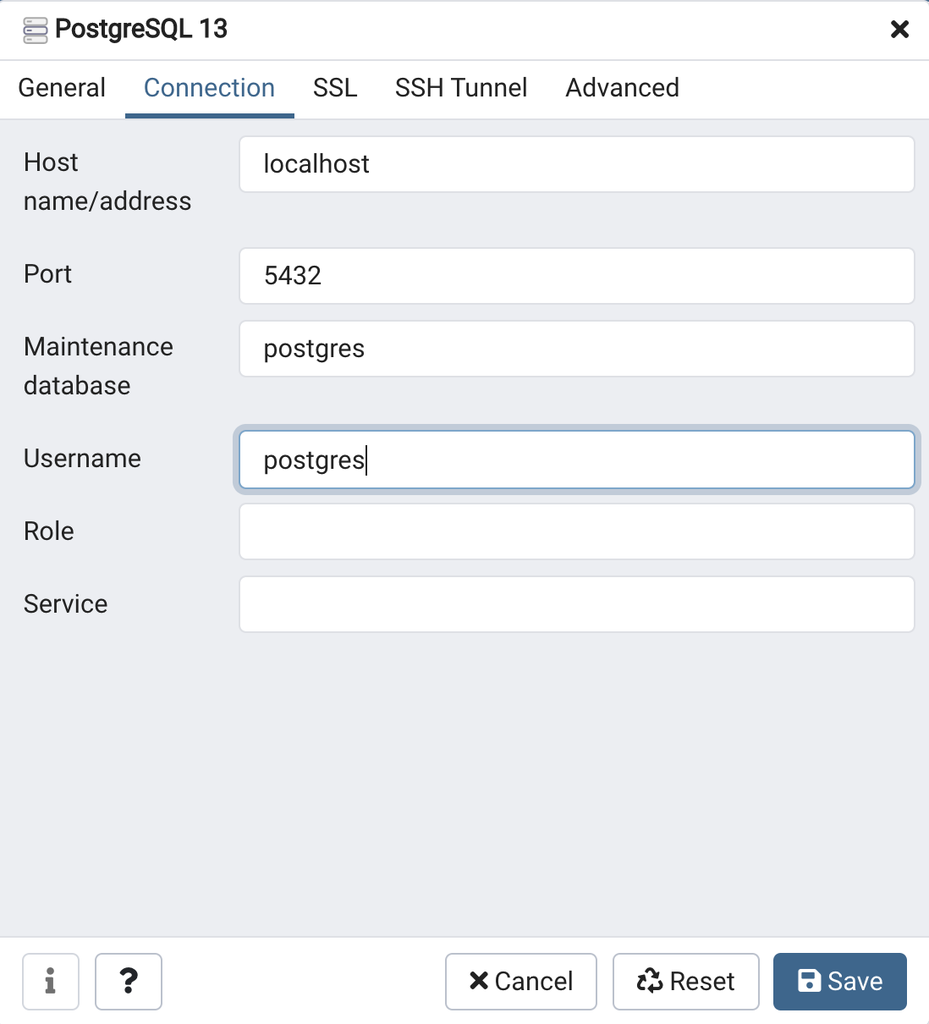

4. Right-click on **PostgreSQL 13** and select `Connect Server`

[figure not shown]

5. When prompted, enter the password you used when you first installed **PostgreSQL** and click the blue **OK** button

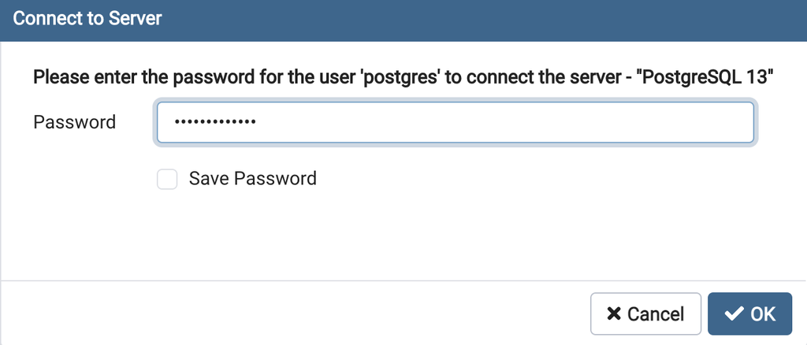

6. Under **Login/Group Roles** in the object browser, right-click on `lake_wa` and select `Delete/Drop`

[figure not shown]